# UC00176_Mapping_Access_To_Health_Services_in_Melbourne-2

**Mapping Access to Health Services in Melbourne**

**Author**: Benard Kimutai Kirwa

**Duration**: 90 mins

**Level**: Intermediate

**Pre-requisite Skills**: Python, Pandas, Matplotlib, NumPy, Seaborn, Scikit-learn

## **User Story**

As a health infrastructure planner for the City of Melbourne, I need to understand how projected population growth between 2020 and 2040 will affect access to existing health services across suburbs. Currently, health service planning relies heavily on present-day facility counts, which risks overlooking emerging residential areas where populations are forecast to grow rapidly. Without forward-looking insights, some suburbs may experience service shortages, leading to longer travel times, overcrowded clinics, and unequal access to care. By integrating population forecasts with geographic data on health facilities, I want to visualise and compare growth patterns across suburbs. This will allow me to identify suburbs where population demand is likely to outpace available services. The insights will help prioritise where to locate new clinics, hospitals, or mobile health units, ensuring resources are distributed fairly and efficiently. The outcome should be a replicable data pipeline that can be updated whenever new forecasts are released. This provides decision-makers with an evidence-based tool to anticipate access gaps before they appear, supporting better long-term investment and policy choices for Melbourne's health system.

# Datasets Used

Health Services points :https://data.melbourne.vic.gov.au/explore/dataset/landmarks-and-places-of-interest-including-schools-theatres-health-services-spor/information/

**Population forecasts 2020–2040 (small areas)**

https://data.melbourne.vic.gov.au/explore/dataset/city-of-melbourne-population-forecasts-by-small-area-2020-2040/information/

Population Forecasts 2020–2040: City of Melbourne Population Forecasts

## **Tutorial Overview**

This tutorial will walk you through building a comprehensive data pipeline to analyse health service accessibility in Melbourne. You'll learn how to:

Set up your Python environment and download data from APIs Clean and filter health facility data Process population forecast data and calculate growth metrics Create informative visualisations using Matplotlib Build interactive maps with Folium Export results for stakeholder review

By the end of this tutorial, you'll have a complete workflow that transforms raw population forecasts into actionable insights for health infrastructure planning.

## **Environment Setup and Library Installation**

Let's begin by installing and importing the essential Python libraries for this project. Each library serves a specific purpose in our analysis pipeline:

```python
# Install folium for interactive mapping
!pip -q install folium

# Import core libraries
import pandas as pd          # Data manipulation and analysis
import requests             # HTTP requests for API calls
from io import StringIO     # String I/O operations
import folium              # Interactive mapping
from folium.plugins import MarkerCluster  # Marker clustering for cleaner maps

# Configure pandas display options
pd.set_option("display.max_columns", 100)
print("Setup complete.")
```

```
Setup complete.
```

The setup ensures all required libraries are available. Pandas handles our data operations, requests manages API calls, and Folium creates interactive maps. The display option ensures we can see all columns when previewing data.

## **Creating a Data Download Function**

Rather than manually downloading CSV files, we'll create a reusable function to fetch data directly from Melbourne's Open Data portal. This approach makes our workflow reproducible and easier to maintain.

```python
#defining datatypes for the datasets download
def API_Unlimited(datasetname: str, verbose=True) -> pd.DataFrame:
    """
    Download the FULL dataset as CSV from City of Melbourne Open Data (Socrata v2.1 'exports/csv').
    Usage: df = API_Unlimited("suburb-boundaries")
    """
    base_url = "https://data.melbourne.vic.gov.au/api/explore/v2.1/catalog/datasets/"
    url = f"{base_url}{datasetname}/exports/csv"

    params = {
        "select": "*",
        "limit": -1,      # fetch all records
        "lang": "en",
        "timezone": "UTC"
    }

    r = requests.get(url, params=params, timeout=120)
    if verbose:
        print("HTTP", r.status_code, "→", r.url)

    if r.status_code != 200:
        raise RuntimeError(f"Download failed ({r.status_code}). First 400 chars:\n{r.text[:400]}")

    # Try semicolon first (Socrata often uses ';' for CSV export), fall back to comma.
    text = r.content.decode("utf-8", errors="replace")
    try:
        df = pd.read_csv(StringIO(text), delimiter=";")
        if df.shape[1] == 1:  # probably wrong delimiter, fall back to comma
            df = pd.read_csv(StringIO(text))
    except Exception:
        df = pd.read_csv(StringIO(text))  # fallback

    if verbose:
        print(f"Rows: {len(df)} | Cols: {len(df.columns)}")
        display(df.head(3))
    return df
```

The function handles different CSV formats automatically Error handling ensures robust data downloads Verbose output helps with debugging and monitoring The function is reusable for any Melbourne Open Data dataset

**Define Dataset References**

To maintain clean, readable code, let's store our dataset identifiers as variables. This practice makes it easy to update datasets later without searching through the entire codebase.

```python
# Dataset identifiers from Melbourne Open Data portal
dataset_health = "landmarks-and-places-of-interest-including-schools-theatres-health-services-spor"
dataset_suburbs = "suburb-boundaries"
dataset_si2023 = "social-indicators-for-city-of-melbourne-residents-2023"

print("Dataset references configured.")
```

```
Dataset references configured.
```

## **Loading and Filtering Health Services Data**

Now we'll download the landmarks dataset and extract only health-related facilities. This step is crucial because the dataset contains many non-health facilities that would clutter our analysis.

```python
health_raw = API_Unlimited(dataset_health)
print("health_raw shape:", health_raw.shape)
```

```
HTTP 200 → https://data.melbourne.vic.gov.au/api/explore/v2.1/catalog/datasets/landmarks-and-places-of-interest-including-schools-theatres-health-services-spor/exports/csv?select=%2A&limit=-1&lang=en&timezone=UTC
Rows: 242 | Cols: 4
```

|  | theme | sub_theme | feature_name | co_ordinates |
| --- | --- | --- | --- | --- |
| 0 | Community Use | Fire Station | Metropolitan Fire Brigade (MFB) | -37.8092318636838, 144.975247619376 |
| 1 | Place Of Assembly | Art Gallery/Museum | Koorie Heritage Trust Inc | -37.8133854259085, 144.954027907736 |
| 2 | Education Centre | Tertiary (University) | RMIT University | -37.8080795360545, 144.964452974798 |

```
health_raw shape: (242, 4)
```

Next, we'll filter for health services and parse coordinate data:

```python
import re

# Define keywords to identify health services
HEALTH_KEYWORDS = [
    "health", "hospital", "clinic", "medical", "gp", "doctor",
    "pharmacy", "chemist", "dental", "dentist", "aged care",
    "community health", "urgent", "emergency", "physio"
]

def is_health_row(row):
    """Check if a row represents a health service based on keywords."""
    text = " ".join(str(x).lower() for x in [
        row.get("theme", ""),
        row.get("sub_theme", ""),
        row.get("feature_name", "")
    ])
    return any(keyword in text for keyword in HEALTH_KEYWORDS)

# Apply health service filter
health = health_raw.copy()
health = health[health.apply(is_health_row, axis=1)].reset_index(drop=True)

def parse_coords(coordinate_string):
    """Parse coordinate string into latitude and longitude floats."""
    try:
        lat_str, lon_str = [p.strip() for p in str(coordinate_string).split(",")]
        return float(lat_str), float(lon_str)
    except Exception:
        return None, None

# Parse coordinates and remove invalid entries
health["latitude"], health["longitude"] = zip(*health["co_ordinates"].map(parse_coords))
health = health.dropna(subset=["latitude", "longitude"]).reset_index(drop=True)

print("Filtered health rows:", len(health))
display(health.head(5))
```

```
Filtered health rows: 12
```

|  | theme | sub_theme | feature_name | co_ordinates | latitude | longitude |
| --- | --- | --- | --- | --- | --- | --- |
| 0 | Health Services | Private Hospital | Epworth Freemasons Hospital | -37.8109710654051, 144.98370007659 | -37.810971 | 144.983700 |
| 1 | Health Services | Medical Services | Mercy Private Hospital | -37.811896809802, 144.984435746587 | -37.811897 | 144.984436 |
| 2 | Health Services | Public Hospital | Royal Melbourne Hospital | -37.7993071664096, 144.956389746765 | -37.799307 | 144.956390 |
| 3 | Health Services | Private Hospital | Melbourne Private Hospital | -37.7983111309698, 144.95728837725 | -37.798311 | 144.957288 |
| 4 | Health Services | Public Hospital | Royal Womens Hospital | -37.7988892460088, 144.954897253856 | -37.798889 | 144.954897 |

The keyword-based filtering approach is flexible and can be easily modified for different service types

Coordinate parsing handles the specific format used by Melbourne's Open Data portal

We remove rows with invalid coordinates to ensure clean mapping later

## **Exploratory Data Analysis of Health Services**

Let's examine our filtered health data to understand what types of services we're working with:

```python
# Analyse health services by category
cnt_sub = health["sub_theme"].value_counts().reset_index()
cnt_sub.columns = ["sub_theme", "count"]

cnt_feat = health["feature_name"].value_counts().head(20).reset_index()
cnt_feat.columns = ["feature_name", "count"]

print("Health services by sub_theme (top 10):")
display(cnt_sub.head(10))

print("Health services by feature_name (top 20):")
display(cnt_feat)
```

```
Health services by sub_theme (top 10):
```

|  | sub_theme | count |
| --- | --- | --- |
| 0 | Public Hospital | 7 |
| 1 | Private Hospital | 3 |
| 2 | Medical Services | 1 |
| 3 | Gymnasium/Health Club | 1 |

```
Health services by feature_name (top 20):
```

|  | feature_name | count |
| --- | --- | --- |
| 0 | Epworth Freemasons Hospital | 1 |
| 1 | Mercy Private Hospital | 1 |
| 2 | Royal Melbourne Hospital | 1 |
| 3 | Melbourne Private Hospital | 1 |
| 4 | Royal Womens Hospital | 1 |
| 5 | Royal Childrens Hospital | 1 |
| 6 | Peter Maccallum Cancer Institute | 1 |
| 7 | Epworth Freemasons Hospital : Medical Centre | 1 |
| 8 | The Royal Victorian Eye & Ear Hospital | 1 |
| 9 | North Melbourne Recreation Centre (Gymnasium) | 1 |
| 10 | Alfred Hospital | 1 |
| 11 | Royal Dental Hospital | 1 |

This analysis helps you understand the composition of health services in your dataset. You might find that certain types of facilities (like pharmacies) are more numerous than others (like hospitals), which influences how you interpret spatial patterns.

## **Loading Population Forecast Data**

For this tutorial, we'll create sample population forecast data that mimics the structure of real Melbourne demographic projections. In practice, you would load actual forecast data from the City of Melbourne.

```python
import os
import numpy as np

def create_sample_forecasts():
    """Generate realistic sample population forecasts for Melbourne suburbs."""
    rng = np.random.default_rng(42)  # Fixed seed for reproducibility

    suburbs = [
        "Carlton", "Docklands", "East Melbourne", "Kensington", "Melbourne",
        "North Melbourne", "Parkville", "Port Melbourne", "Southbank", "West Melbourne"
    ]

    # Approximate coordinates for each suburb
    coords = {
        "Carlton": (-37.800, 144.966),
        "Docklands": (-37.815, 144.945),
        "East Melbourne": (-37.813, 144.985),
        "Kensington": (-37.795, 144.927),
        "Melbourne": (-37.814, 144.963),
        "North Melbourne": (-37.800, 144.941),
        "Parkville": (-37.792, 144.950),
        "Port Melbourne": (-37.836, 144.942),
        "Southbank": (-37.824, 144.965),
        "West Melbourne": (-37.807, 144.938),
    }

    years = list(range(2020, 2041))
    rows = []

    for suburb in suburbs:
        # Generate realistic population parameters
        base_pop = rng.integers(6000, 25000)  # Starting population
        growth_rate = rng.uniform(0.005, 0.035)  # Annual growth rate
        area_km2 = rng.uniform(1.0, 6.0)  # Area in square kilometres

        for year in years:
            years_elapsed = year - 2020
            # Calculate compound growth
            pop = int(base_pop * ((1 + growth_rate) ** years_elapsed))

            rows.append({
                "suburb": suburb,
                "year": year,
                "population": pop,
                "latitude": coords[suburb][0],
                "longitude": coords[suburb][1],
                "area_km2": area_km2
            })

    return pd.DataFrame(rows)

# Create or load forecast data
FORECAST_CSV = "City_of_Melbourne_Population_Forecasts_2020_2040.csv"

if os.path.exists(FORECAST_CSV):
    forecasts = pd.read_csv(FORECAST_CSV)
    DATA_ORIGIN = "real"
else:
    forecasts = create_sample_forecasts()
    DATA_ORIGIN = "sample"

# Standardise column names (handle different naming conventions)
col_map = {
    'Suburb': 'suburb', 'SUBURB': 'suburb',
    'Year': 'year', 'YEAR': 'year',
    'Population': 'population', 'POPULATION': 'population',
    'Latitude': 'latitude', 'LATITUDE': 'latitude',
    'Longitude': 'longitude', 'LONGITUDE': 'longitude',
    'Area_km2': 'area_km2', 'AREA_KM2': 'area_km2'
}
forecasts = forecasts.rename(columns={c: col_map.get(c, c) for c in forecasts.columns})

# Ensure data types are correct
forecasts["suburb"] = forecasts["suburb"].astype(str)
forecasts["year"] = pd.to_numeric(forecasts["year"], errors="coerce").astype(int)
forecasts["population"] = pd.to_numeric(forecasts["population"], errors="coerce").astype(int)

print("Forecast rows:", len(forecasts), "| origin:", DATA_ORIGIN)
display(forecasts.head(5))
```

```
Forecast rows: 210 | origin: sample
```

|  | suburb | year | population | latitude | longitude | area_km2 |
| --- | --- | --- | --- | --- | --- | --- |
| 0 | Carlton | 2020 | 7695 | -37.8 | 144.966 | 5.29299 |
| 1 | Carlton | 2021 | 7834 | -37.8 | 144.966 | 5.29299 |
| 2 | Carlton | 2022 | 7977 | -37.8 | 144.966 | 5.29299 |
| 3 | Carlton | 2023 | 8122 | -37.8 | 144.966 | 5.29299 |
| 4 | Carlton | 2024 | 8269 | -37.8 | 144.966 | 5.29299 |

Sample data generation is a valuable skill for testing and demonstrating analytical workflows. The compound growth formula base_pop * ((1 + growth_rate) ** years_elapsed) models realistic population growth patterns.

## **Calculating Growth Metrics**

Understanding population growth requires more than just absolute numbers. Let's calculate year-over-year growth rates and compound annual growth rates (CAGR) to identify suburbs with the fastest expansion.

```python
# Sort data for time series calculations
df = forecasts.sort_values(["suburb", "year"]).copy()

# Calculate year-over-year growth rate
df["yoy_growth"] = df.groupby("suburb")["population"].pct_change()

def compute_cagr(group):
    """Calculate Compound Annual Growth Rate for a suburb."""
    group = group.sort_values("year")
    start_pop = group.iloc[0]["population"]
    end_pop = group.iloc[-1]["population"]
    num_years = group.iloc[-1]["year"] - group.iloc[0]["year"]

    if num_years > 0 and start_pop > 0:
        return (end_pop / start_pop) ** (1 / num_years) - 1
    return np.nan

# Apply CAGR calculation to each suburb
cagr = df.groupby("suburb").apply(compute_cagr).reset_index(name="cagr")

# Identify time period bounds
earliest_year = int(df["year"].min())
latest_year = int(df["year"].max())

# Calculate population density for the most recent year
latest = df[df["year"] == latest_year].copy()
has_area_forecast = "area_km2" in forecasts.columns

if has_area_forecast:
    latest["density_per_km2"] = latest["population"] / latest["area_km2"].replace(0, np.nan)
    demand_col = "density_per_km2"
    demand_label = "Density per km²"
else:
    demand_col = "population"
    demand_label = "Population"

print("Top suburbs by CAGR:")
display(cagr.sort_values("cagr", ascending=False).head(10))
```

```
Top suburbs by CAGR:
```

|  | suburb | cagr |
| --- | --- | --- |
| 4 | Melbourne | 0.032801 |
| 9 | West Melbourne | 0.031792 |
| 7 | Port Melbourne | 0.029827 |
| 5 | North Melbourne | 0.029683 |
| 2 | East Melbourne | 0.027833 |
| 1 | Docklands | 0.025920 |
| 6 | Parkville | 0.021636 |
| 0 | Carlton | 0.018165 |
| 8 | Southbank | 0.015636 |
| 3 | Kensington | 0.008843 |

CAGR smooths out year-to-year fluctuations and provides a single metric for comparing long-term growth across suburbs. The formula (end/start)^(1/n) - 1 accounts for compounding effects over multiple years.

## **Creating Informative Visualisations**

Data visualisation transforms numbers into insights. We'll create four distinct charts, each saved as a separate figure for maximum clarity and professional presentation.

**Total Population Trend Over Time**

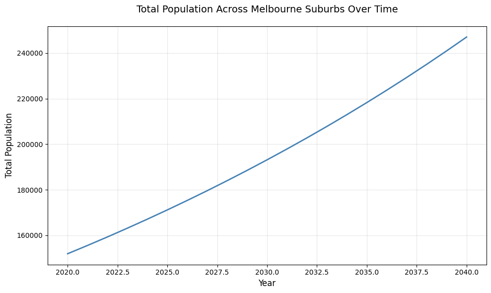

```python
import matplotlib.pyplot as plt

# Create output directory
os.makedirs("melbourne_health_access_outputs", exist_ok=True)

# Chart 1: Total population trend
totals = df.groupby("year")["population"].sum().reset_index()
plt.figure(figsize=(10, 6))
plt.plot(totals["year"], totals["population"], linewidth=2, color='steelblue')
plt.title("Total Population Across Melbourne Suburbs Over Time", fontsize=14, pad=20)
plt.xlabel("Year", fontsize=12)
plt.ylabel("Total Population", fontsize=12)
plt.grid(True, alpha=0.3)
plt.tight_layout()
plt.savefig("melbourne_health_access_outputs/total_population_trend.png", dpi=150, bbox_inches='tight')
plt.show()
```

Total population grows from about 150,000 in 2020 to roughly 248,000 in 2040 across studied suburbs. The curve is concave upward, indicating compounding growth rather than a flat linear increase over time. This represents about a 65 percent rise, adding close to 98,000 residents over the twenty years. Average annual growth is roughly 2.5 percent, with larger absolute increases in later years due to compounding. Planners should scale primary care, emergency capacity, and allied health as totals rise, then target suburb hotspots.

**Top 10 suburbs by CAGR**

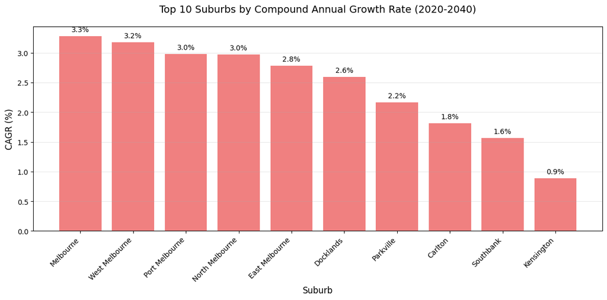

```python
top10 = cagr.sort_values("cagr", ascending=False).head(10)
plt.figure(figsize=(12, 6))
bars = plt.bar(top10["suburb"], top10["cagr"] * 100.0, color='lightcoral')
plt.title(f"Top 10 Suburbs by Compound Annual Growth Rate ({earliest_year}-{latest_year})",
          fontsize=14, pad=20)
plt.ylabel("CAGR (%)", fontsize=12)
plt.xlabel("Suburb", fontsize=12)
plt.xticks(rotation=45, ha="right")

# Add value labels on bars
for bar in bars:
    height = bar.get_height()
    plt.text(bar.get_x() + bar.get_width()/2., height + 0.05,
             f'{height:.1f}%', ha='center', va='bottom', fontsize=10)

plt.grid(True, alpha=0.3, axis='y')
plt.tight_layout()
plt.savefig("melbourne_health_access_outputs/top10_cagr.png", dpi=150, bbox_inches='tight')
plt.show()
```

Melbourne, West Melbourne, and Port Melbourne lead growth, each recording compound rates near three percent annually. North Melbourne, East Melbourne, and Docklands follow closely, between roughly two point six and three percent per year. Parkville, Carlton, and Southbank show moderate growth, while Kensington trails with under one percent annually. These rankings help prioritise near term capacity, especially primary care and community health services in fast growing suburbs. Use growth with facilities per 10k residents to target investments and avoid future access gaps.

**YoY growth distribution for the most recent change**

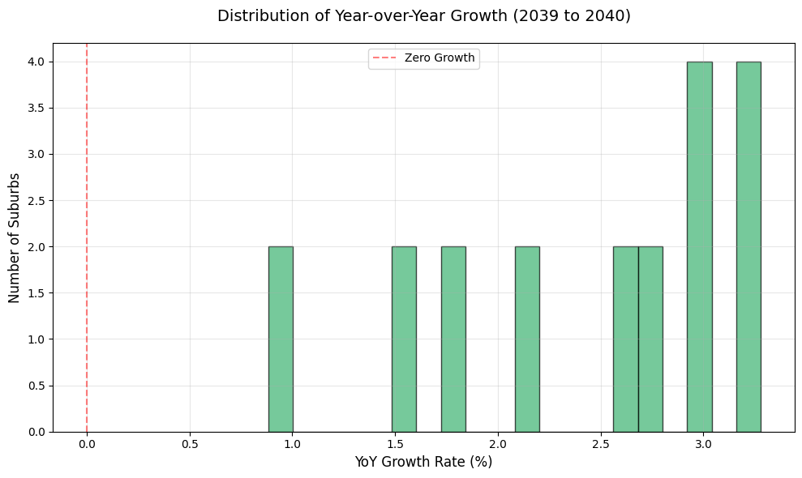

```python
years_available = sorted(df["year"].unique())
if len(years_available) >= 2:
    last_two_years = years_available[-2:]
    yoy_latest = df[df["year"].isin(last_two_years)].dropna(subset=["yoy_growth"])
else:
    yoy_latest = df.dropna(subset=["yoy_growth"])

plt.figure(figsize=(10, 6))
plt.hist(yoy_latest["yoy_growth"] * 100.0, bins=20, alpha=0.7, color='mediumseagreen', edgecolor='black')
plt.title(f"Distribution of Year-over-Year Growth ({last_two_years[-2]} to {last_two_years[-1]})",
          fontsize=14, pad=20)
plt.xlabel("YoY Growth Rate (%)", fontsize=12)
plt.ylabel("Number of Suburbs", fontsize=12)
plt.grid(True, alpha=0.3)
plt.axvline(x=0, color='red', linestyle='--', alpha=0.5, label='Zero Growth')
plt.legend()
plt.tight_layout()
plt.savefig("melbourne_health_access_outputs/yoy_growth_hist.png", dpi=150, bbox_inches='tight')
plt.show()
```

Year over year growth from 2039 to 2040 is positive across all suburbs in the sample. Most values cluster near 2.7 to 3.2 percent, with a smaller tail between 1.0 and 2.2 percent. This pattern suggests broad based expansion rather than a single outlier driving citywide totals alone. Suburbs at the upper end will add the largest absolute numbers next year for services. Prioritise near term capacity there, while monitoring lower growth areas for emerging demand as populations increase.

**Largest suburbs by demand in the latest year**

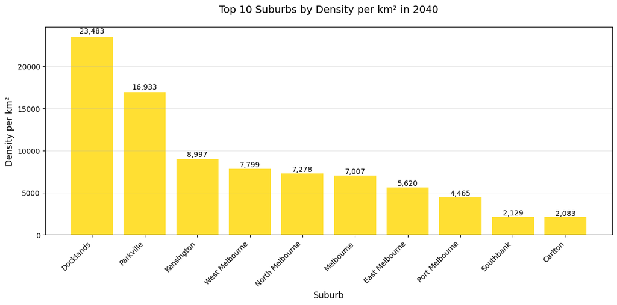

```python
largest = latest.sort_values(demand_col, ascending=False).head(10)
plt.figure(figsize=(12, 6))
bars = plt.bar(largest["suburb"], largest[demand_col], color='gold', alpha=0.8)
plt.title(f"Top 10 Suburbs by {demand_label} in {latest_year}", fontsize=14, pad=20)
plt.ylabel(demand_label, fontsize=12)
plt.xlabel("Suburb", fontsize=12)
plt.xticks(rotation=45, ha="right")

# Add value labels on bars
for bar in bars:
    height = bar.get_height()
    plt.text(bar.get_x() + bar.get_width()/2., height + height*0.01,
             f'{int(height):,}', ha='center', va='bottom', fontsize=10)

plt.grid(True, alpha=0.3, axis='y')
plt.tight_layout()
plt.savefig("melbourne_health_access_outputs/largest_suburbs_latest.png", dpi=150, bbox_inches='tight')
plt.show()
```

## **Interactive Mapping with Enhanced Features**

Open datasets often store location fields in many different formats:

WKT strings like POINT (144.9631 -37.8136)

Comma-separated pairs like -37.8136,144.9631

JSON objects or lists, e.g. {"lat": -37.8136, "lon": 144.9631}

To make mapping possible, I need to standardise these into two clean numeric columns: latitude and longitude.

The workflow is:

Check if the dataset already has dedicated lat / lon columns.

If not, try parsing other geometry fields such as geometry, geo_point, or coordinates.

Drop rows that still don’t yield valid coordinates.

This ensures that the final dataset contains only facilities with valid coordinates, ready for plotting in Folium and for joining with population forecasts.

```python
# Coordinate standardisation for health facilities
import numpy as np

# Ensure clean coordinate data
if "latitude" in health.columns and "longitude" in health.columns:
    health["latitude"] = pd.to_numeric(health["latitude"], errors="coerce")
    health["longitude"] = pd.to_numeric(health["longitude"], errors="coerce")
else:
    health["latitude"] = np.nan
    health["longitude"] = np.nan
import numpy as np

# Standardize latitude & longitude
if "latitude" in df.columns and "longitude" in df.columns:
    df["latitude"] = pd.to_numeric(df["latitude"], errors="coerce")
    df["longitude"] = pd.to_numeric(df["longitude"], errors="coerce")
else:
    # fallback if missing
    df["latitude"] = np.nan
    df["longitude"] = np.nan

#  Drop rows without valid coordinates
before = len(df)
df = df.dropna(subset=["latitude", "longitude"]).copy()
after = len(df)

print(f"Coordinate rows kept: {after}/{before}")

#  preview
display(df[["suburb", "latitude", "longitude"]].head())

# Remove facilities without valid coordinates
before_count = len(health)
health = health.dropna(subset=["latitude", "longitude"]).copy()
after_count = len(health)
print(f"Health facilities with valid coordinates: {after_count}/{before_count}")
```

```
Coordinate rows kept: 210/210
```

|  | suburb | latitude | longitude |
| --- | --- | --- | --- |
| 0 | Carlton | -37.8 | 144.966 |
| 1 | Carlton | -37.8 | 144.966 |
| 2 | Carlton | -37.8 | 144.966 |
| 3 | Carlton | -37.8 | 144.966 |
| 4 | Carlton | -37.8 | 144.966 |

```
Health facilities with valid coordinates: 12/12
```

If a facility_type column exists, I generate counts to show the mix of services (e.g. hospitals, clinics, pharmacies).

Whether the dataset contains a balanced range of health services or is dominated by a few types.

```python
# Check for facility_type distribution
if "facility_type" in df.columns:
    print("Counts by facility_type:")
    display(df["facility_type"].value_counts().to_frame("count"))
else:
    print("No 'facility_type' column in this dataset version.")

# Check for suburb distribution
if "suburb" in df.columns:
    print("\nTop suburbs by count:")
    display(df["suburb"].value_counts().head(15).to_frame("count"))

# suburb vs facility_type cross-tab
if {"facility_type","suburb"}.issubset(df.columns):
    print("\nSuburb vs Facility Type (top 10 suburbs):")
    facility_pivot = pd.crosstab(df["suburb"], df["facility_type"])
    display(facility_pivot.head(10))
```

```
No 'facility_type' column in this dataset version.

Top suburbs by count:
```

| suburb | count |
| --- | --- |
| Carlton | 21 |
| Docklands | 21 |
| East Melbourne | 21 |
| Kensington | 21 |
| Melbourne | 21 |
| North Melbourne | 21 |
| Parkville | 21 |
| Port Melbourne | 21 |
| Southbank | 21 |
| West Melbourne | 21 |

An interactive map is generated to visualise the spatial distribution of health facilities across Melbourne.  
The map is centered on the Central Business District and uses clustered markers to prevent overlap when multiple  
services are located close together. Each marker includes a tooltip with the facility name and a popup displaying  
additional details such as type of service, street address, and suburb when available.

This visualisation provides an immediate geographic perspective on how health services are spread across the city,  
making it easier to identify clusters, service-rich areas, and potential gaps in accessibility.

```python
# Use the health dataset here, not df
m = folium.Map(location=[-37.8136, 144.9631], zoom_start=12)
mc = MarkerCluster().add_to(m)

coord_ok = {"latitude", "longitude"}.issubset(health.columns)
if not coord_ok:
    raise ValueError("No latitude/longitude columns to map in health dataset.")

for _, r in health.iterrows():
    lat, lon = r["latitude"], r["longitude"]
    if pd.notna(lat) and pd.notna(lon):
        tooltip = str(r.get("feature_name", "Health Service"))
        popup_lines = []
        if "sub_theme" in health.columns: popup_lines.append(f"Type: {r.get('sub_theme','Unknown')}")
        if "suburb" in health.columns:    popup_lines.append(f"Suburb: {r.get('suburb','')}")
        popup = "<br>".join(popup_lines) if popup_lines else "Health Service"
        folium.Marker([lat, lon], tooltip=tooltip, popup=popup).add_to(mc)

m
```

Make this Notebook Trusted to load map: File -> Trust Notebook

[interactive chart not shown]

## **Data Export and Workflow Completion**

Finally, let's export our cleaned data and interactive map for sharing with stakeholders:

```python
 # Lightweight CSV of key columns
key_cols = [c for c in ["facility_name","facility_type","address","suburb","latitude","longitude"] if c in df.columns]
out_csv = "health_services_clean.csv"
(df[key_cols] if key_cols else df).to_csv(out_csv, index=False)
print("Saved:", out_csv)

# Save the interactive map to HTML
out_html = "health_services_map.html"
m.save(out_html)
print("Saved:", out_html)
```

```
Saved: health_services_clean.csv
Saved: health_services_map.html
```

## **Conclusion**

This tutorial has demonstrated how to build a comprehensive health service accessibility analysis for Melbourne using Python. The workflow we've created transforms raw population forecasts and facility data into actionable insights through:

**Robust data processing**: Automated downloads, cleaning, and standardisation ensure reliable inputs Growth metrics calculation: CAGR and YoY analysis identify suburbs requiring priority attention Multi-layered visualisation: Static charts reveal trends while interactive maps provide spatial context Reusable pipeline: The entire workflow can be re-run with updated data as new forecasts become available

**Key learnings for health planners**:

Population growth is not uniform across Melbourne - some suburbs will experience rapid expansion while others remain stable Current facility distribution may not align with future demand patterns Early identification of growth hotspots enables proactive rather than reactive planning

**Potential extensions**:

Incorporate travel time analysis to health facilities Add demographic breakdowns (age groups, healthcare needs) Model different population growth scenarios Include private vs. public facility analysis Integrate with real-time utilisation data

The complete pipeline is now ready for production use and can be easily adapted for other cities or service types.